# MIE237

2016-03-01

## New Topic: Correlation

## Preview of "correlation" (from 2016-01-29)

Recall \(\text{Cov}(X,Y) = E(X-E(X))(Y-E(Y)) = E(XY)-E(X)E(Y)\).

Measures linear relationship between \(X\) and \(Y\).

A related measure that divides by the two standard deviations:\[\rho = \frac{\text{Cov}(X,Y)}{\sqrt{{\text{Var}\left( X \right)} {\text{Var}\left( Y \right)}}}\]

"Correlation coefficient" \(\rho\) is a measure of the linear relationship between the random variables \(X\) and \(Y\). We'd like an analogous *empirical* measure for *sample data*.

## Correlation

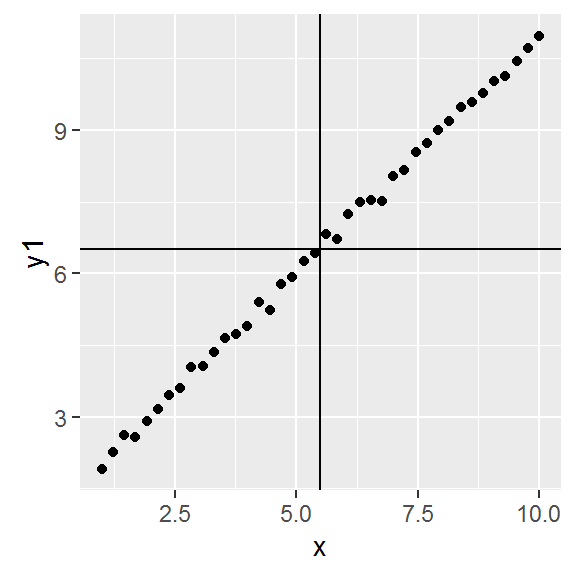

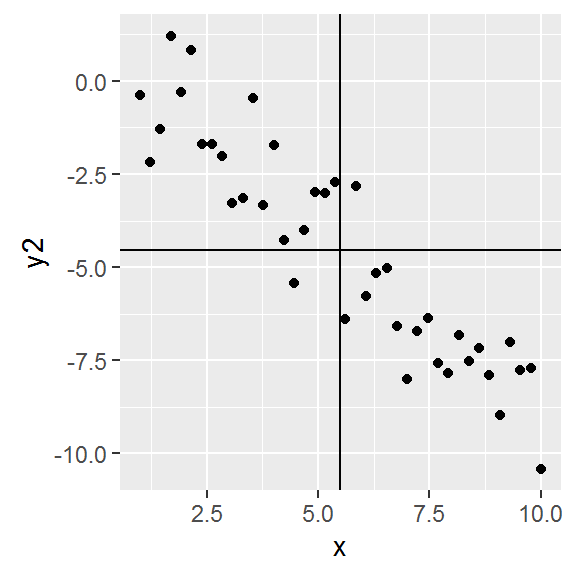

'Twill be based on:\[S_{xy}=\sum_{i=1}^n \left(x_i-\overline x\right) \left(y_i - \overline y\right)\]

## Sample correlation coefficient

Define:\[r = \frac{S_{xy}}{\sqrt{S_{xx}{S_{yy}}}}\]

\(r\) is an estimator of \(\rho\), called the "sample correlation coefficient".

In regression analysis the \(x\) variable is considered fixed, and \(y\) is a function of \(x\).

Correlation is a property of \(Y\) and \(X\) both random, and correlation is symmetric in \(X\) and \(Y\).

Nevertheless we use (misuse?) sample correlation coefficient also in a regression context as a useful numerical summary of a bivariate relationship.

## Connection with \(R^2\)

Recall that \(S_{yy} = \sum (y_i - {\overline{y}})^2 = SST\) and \(R^2 = SSR\big/SST = 1-SSE\big/SST\).

It turns out also that \(SSE = S_{yy} - \hat\beta_1S_{xy}\). So:\[\begin{align*} R^2 &= 1 - \frac{SSE}{SST}\\ &= 1 - \frac{S_{yy} - \hat\beta_1S_{xy}}{S_{yy}}\\ &= 1 - \left(1 - \frac{\hat\beta_1S_{xy}}{S_{yy}}\right)\\ &= \frac{S_{xy}^2}{S_{xx}S_{yy}} = (r)^2\end{align*}\]

## Other properties of \(r\)

Since \(0 \le R^2 \le 1\) it follows \(-1 \le r \le 1\).

It is possible to do things like test \(H_0: \rho=0\) versus \(H_1: \rho\ne 0\) using \(r\), but we will not cover this.

## Examples

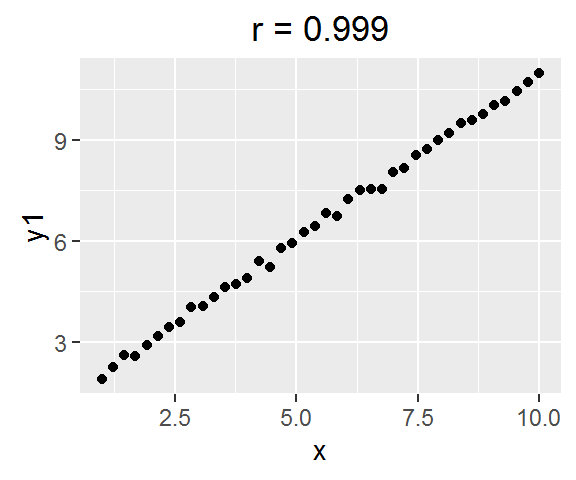

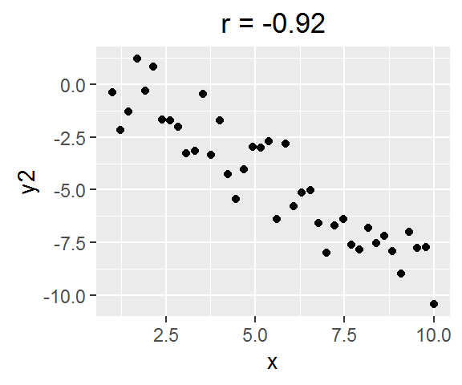

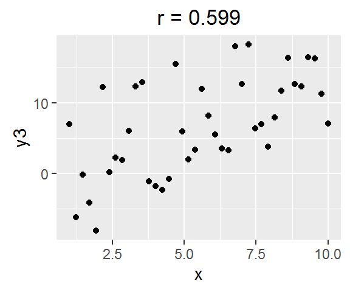

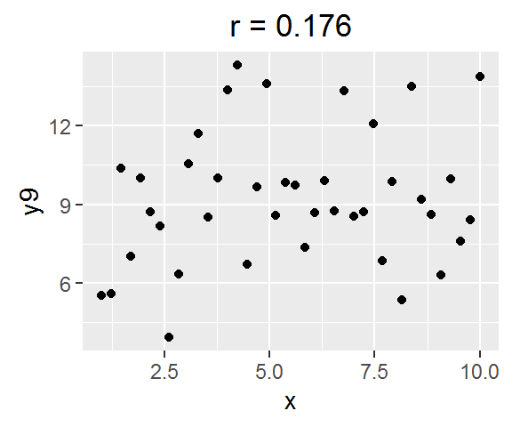

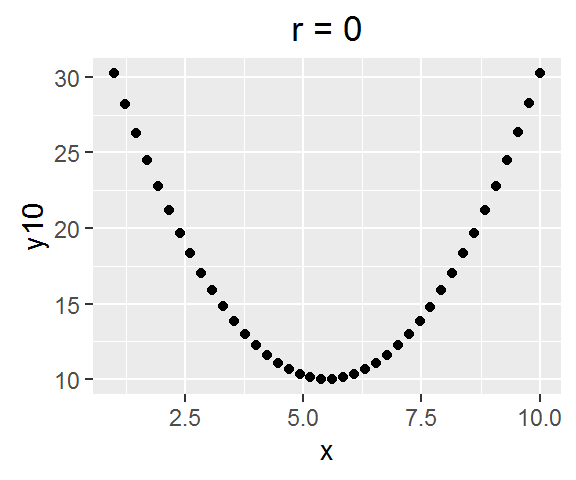

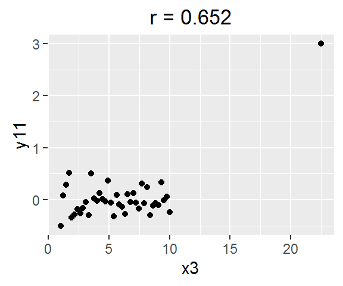